# WB XAI-2

Jung Jakub, Majchrzak Martyna, Niewiadowski Paweł

9.05.2021

```r
m <- sample(1:nrow(diabetes), 0.7*nrow(diabetes))
diabetes_train <- diabetes[m,]
diabetes_test <- diabetes[-m,]
classif_task <- makeClassifTask(id = "lvr", data = diabetes_train, target = "class")
classif_lrn <- makeLearner("classif.ranger", predict.type = "prob")
model <- train(classif_lrn, classif_task)

explainer <- DALEX::explain(model = model,
                     data = diabetes,
                     y = diabetes$class)
```

## Data description

In the dataset there are 8 features and 1 target.

- `preg` : number of pregnancies
- `plas` : plasma glucose concentration (mg/dL) at 2 hours in an OGTT (oral glucose tolerance test) - a test in which subject is given glucose and blood samples are taken afterward to determine how quickly it is cleared from the blood
- `pres` : blood pressure (mm Hg)
- `skin` : triceps skinfold thickness (mm) measured at the back of the left arm. A measurement giving rough information about body fat percentage.
- `insu` : 2-hour serum insulin (mu U/ml)
- `mass` : BMI index (weight in kg/(height in meters)^2)
- `pedi` : diabetes pedigree function outcome, where DBF is a function that uses information from parents, grandparents, siblings, aunts and uncles, and first cousins and provides a measure of the expected genetic influence of affected and unaffected relatives on the subject’s eventual diabetes risk
- `age` : age (years)
- `class` (target): 1 if tested positive for diabetes, 0 otherwise

## Variable importance

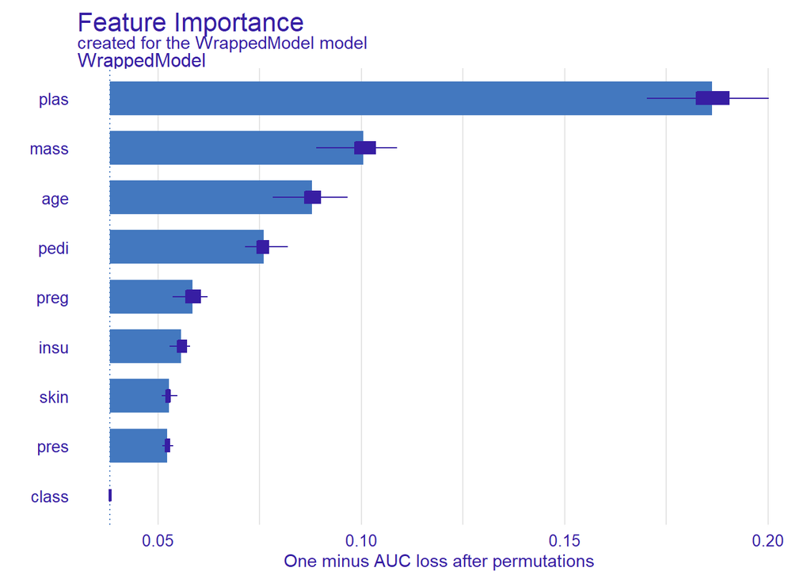

```r
fi_1 <- model_parts(explainer, B = 10)
plot(fi_1)
```

## Average influence on prediction

### PDP

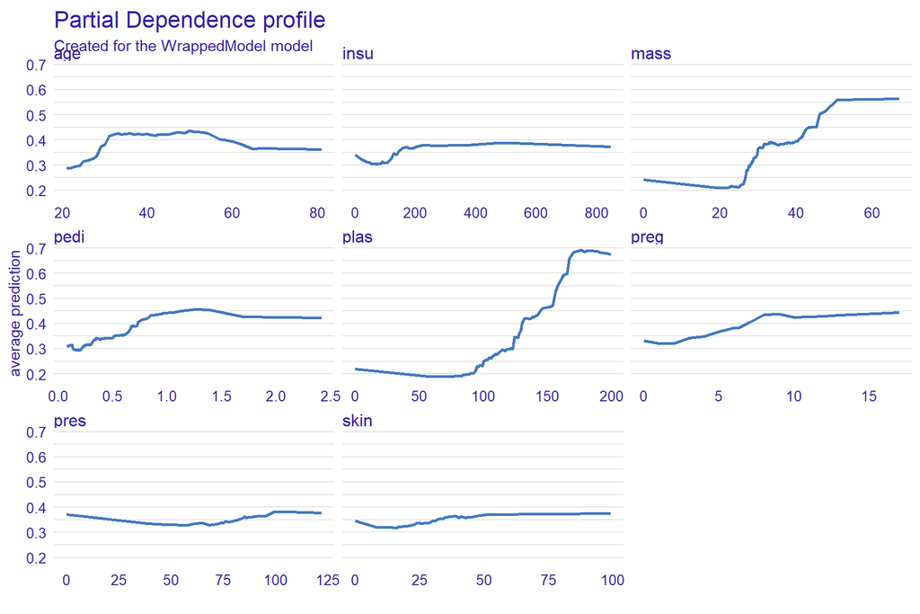

```r
pdp_1 <- model_profile(explainer)
plot(pdp_1)
```

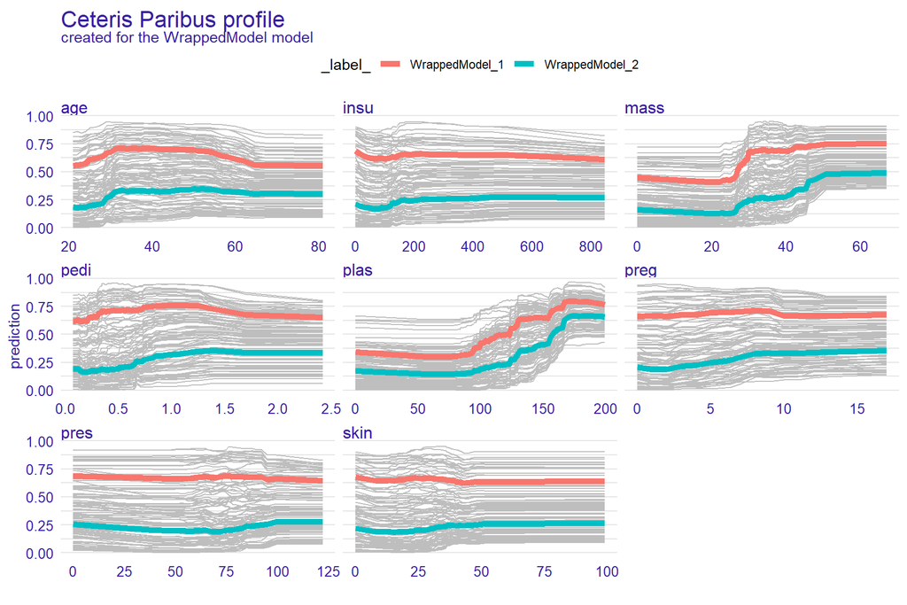

```r
pdp_2 <- model_profile(explainer,k=2)
plot(pdp_2, geom = "profiles")
```

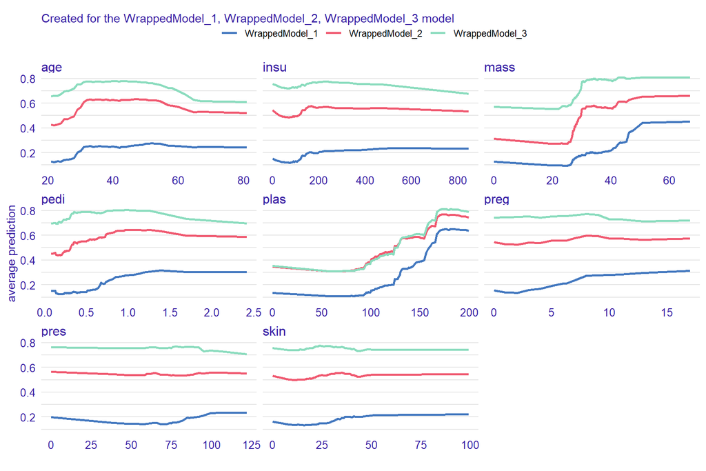

```r
pdp_3 <- model_profile(explainer,k=3)
plot(pdp_3)
```

### ALE

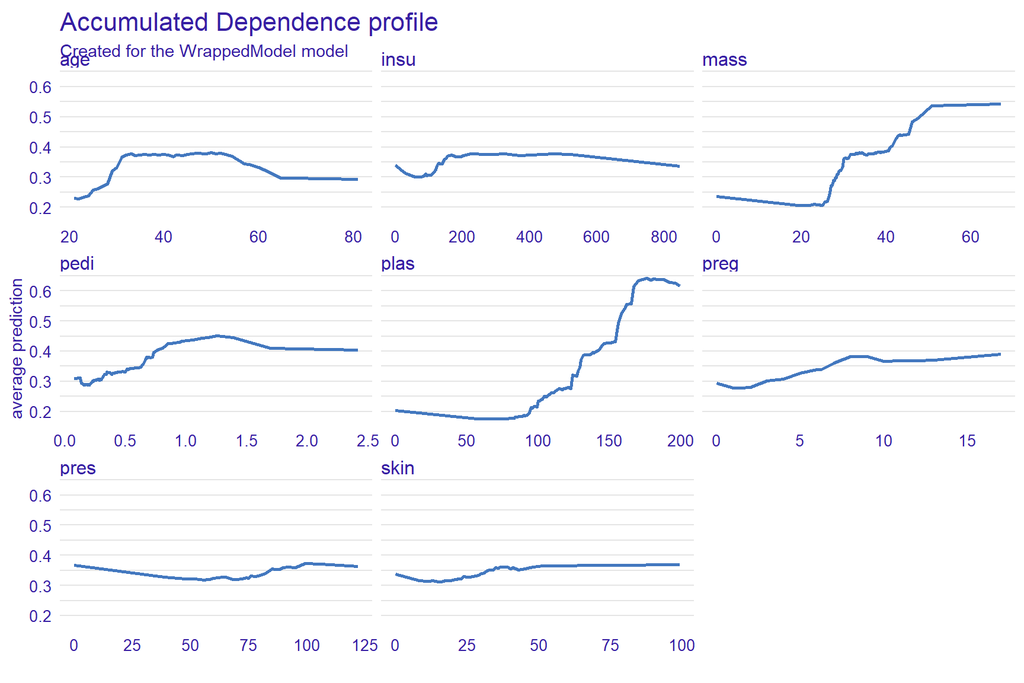

```r
ale_1 <- model_profile(explainer,type="accumulated")
plot(ale_1)
```

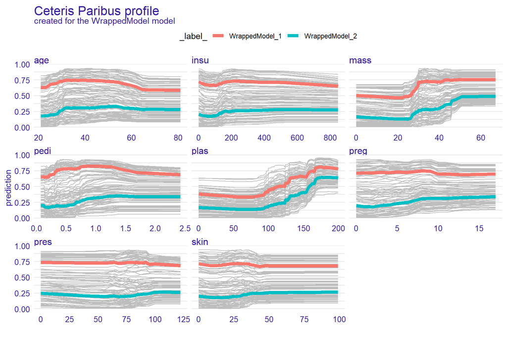

```r
ale_2 <- model_profile(explainer,k=2,type="accumulated")
plot(ale_2, geom = "profiles")
```

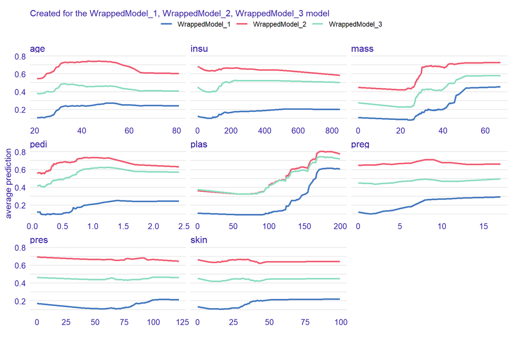

```r
ale_3 <- model_profile(explainer,k=3,type="accumulated")
plot(ale_3)
```

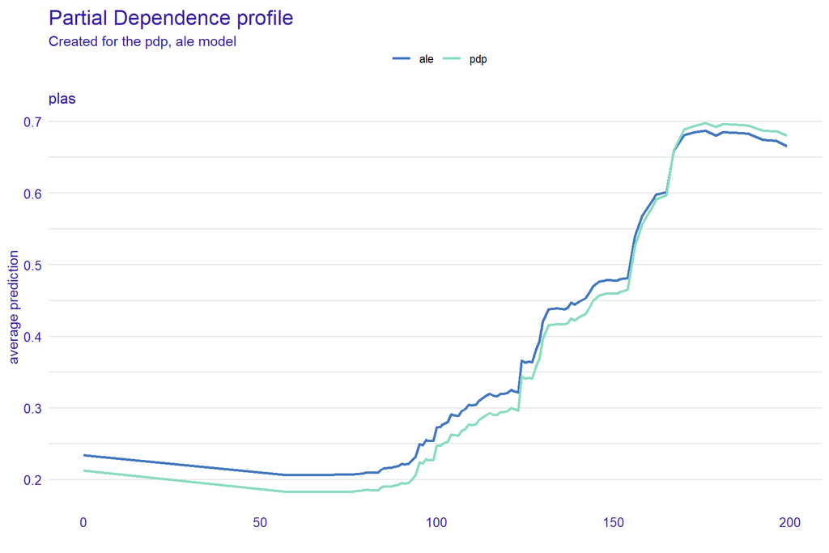

```r
pdp_4 <- model_profile(explainer, variables = "plas")
ale_4 <- model_profile(explainer, variables = "plas",type="accumulated")
ale_4$agr_profiles$`_label_` <- "ale"
pdp_4$agr_profiles$`_label_` <- "pdp"
plot(pdp_4,ale_4)
```

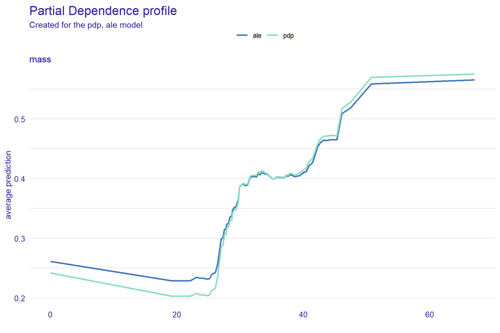

```r
pdp_5 <- model_profile(explainer, variables = "mass")
ale_5 <- model_profile(explainer, variables = "mass",type="accumulated")
ale_5$agr_profiles$`_label_` <- "ale"
pdp_5$agr_profiles$`_label_` <- "pdp"
plot(pdp_5,ale_5)
```